# 言語処理100本ノック／第8章: 機械学習

### No.76

学習データに対してロジスティック回帰モデルを適用し，正解のラベル，予測されたラベル，予測確率をタブ区切り形式で出力せよ．

```python
# (1となる)予測確率を取り出す
prob_list = []
for item in (log_model.predict_proba(corpus_data_features_nd[0:len(sentence_df)])).tolist():
    prob_list.append(item[1])
```

```python
# 予測されたラベル
predicted_list = []
for item in (log_model.predict(corpus_data_features_nd[0:len(sentence_df)])).tolist():
    predicted_list.append(item)
```

```python
# 正解のラベル
answer_list = sentence_df.Sentiment.tolist()
```

```python
c = 0
for ans, pred, prob in zip(answer_list, predicted_list, prob_list):
    print("\t".join([str(ans), str(pred), str(prob)]))
    c += 1

    if c > 15:
        break
```

```
1	0	0.4579967855164436
0	0	0.36339089380602546
1	1	0.8979128323063421
0	0	0.16267648262119266
0	0	0.061397031341404874
1	1	0.8886019598464954
1	1	0.9845337307099536
1	1	0.6458626033030465
0	0	0.10923439674725906
1	1	0.8468656614584312
0	0	0.20820815633568987
0	0	0.19377827347175378
0	0	0.04822805183307073
0	0	0.08711191693191175
0	0	0.05280003895603099
0	0	0.1385492848570509
```

### No.77

76の出力を受け取り，予測の正解率，正例に関する適合率，再現率，F1スコアを求めるプログラムを作成せよ．

```python
from sklearn.metrics import classification_report

y_pred = log_model.predict(corpus_data_features_nd[0:len(sentence_df)])
target_names = ['0: negative', '1: positive']
print(classification_report(sentence_df.Sentiment, y_pred, target_names=target_names))
```

```
             precision    recall  f1-score   support

0: negative       0.92      0.93      0.92      5331
1: positive       0.93      0.92      0.92      5330

avg / total       0.92      0.92      0.92     10661
```

### No.78

76-77の実験では，学習に用いた事例を評価にも用いたため，正当な評価とは言えない．すなわち，分類器が訓練事例を丸暗記する際の性能を評価しており，モデルの汎化性能を測定していない．そこで，5分割交差検定により，極性分類の正解率，適合率，再現率，F1スコアを求めよ．

交差検定については[こちら](http://d.hatena.ne.jp/hoxo_m/20110324/p1)の説明を参考に。

```python
len(sentence_df)
```

```
10661
```

今回の長さは10661なので、[0:2000] [2001:4000] [4001:6000] [6001:8000] [8001:10661] の5つのグループに分けることにする

##### No.1

```python
X_train = corpus_data_features_nd[2001:]
X_test = corpus_data_features_nd[0:2000]
y_train = sentence_df.Sentiment[2001:]
y_test = sentence_df.Sentiment[0:2000]
```

```python
log_model = LogisticRegression()
log_model = log_model.fit(X=X_train, y=y_train)
y_pred = log_model.predict(X_test)
print(classification_report(y_test, y_pred))
```

```
             precision    recall  f1-score   support

          0       0.74      0.76      0.75      1003
          1       0.76      0.73      0.75       997

avg / total       0.75      0.75      0.75      2000
```

##### No.2

```python
x_train_index = [i for i in range(0, 2000)] + [i for i in range(4001, len(corpus_data_features_nd))]

X_train = corpus_data_features_nd[x_train_index]
X_test = corpus_data_features_nd[2001:4000]
y_train = pd.concat([sentence_df.Sentiment[0:2000] , sentence_df.Sentiment[4001:len(corpus_data_features_nd)]])
y_test = sentence_df.Sentiment[2001:4000]

log_model = LogisticRegression()
log_model = log_model.fit(X=X_train, y=y_train)
y_pred = log_model.predict(X_test)
print(classification_report(y_test, y_pred))
```

```
             precision    recall  f1-score   support

          0       0.74      0.73      0.74      1022
          1       0.72      0.73      0.73       977

avg / total       0.73      0.73      0.73      1999
```

##### No.3

```python
x_train_index = [i for i in range(0, 4000)] + [i for i in range(6001, len(corpus_data_features_nd))]

X_train = corpus_data_features_nd[x_train_index]
X_test = corpus_data_features_nd[4001:6000]
y_train = pd.concat([sentence_df.Sentiment[0:4000] , sentence_df.Sentiment[6001:len(corpus_data_features_nd)]])
y_test = sentence_df.Sentiment[4001:6000]

log_model = LogisticRegression()
log_model = log_model.fit(X=X_train, y=y_train)
y_pred = log_model.predict(X_test)
print(classification_report(y_test, y_pred))
```

```
             precision    recall  f1-score   support

          0       0.72      0.72      0.72       989
          1       0.73      0.72      0.73      1010

avg / total       0.72      0.72      0.72      1999
```

##### No.4

```python
x_train_index = [i for i in range(0, 6000)] + [i for i in range(8001, len(corpus_data_features_nd))]

X_train = corpus_data_features_nd[x_train_index]
X_test = corpus_data_features_nd[6001:8000]
y_train = pd.concat([sentence_df.Sentiment[0:6000] , sentence_df.Sentiment[8001:len(corpus_data_features_nd)]])
y_test = sentence_df.Sentiment[6001:8000]

log_model = LogisticRegression()
log_model = log_model.fit(X=X_train, y=y_train)
y_pred = log_model.predict(X_test)
print(classification_report(y_test, y_pred))
```

```
             precision    recall  f1-score   support

          0       0.74      0.75      0.75       988
          1       0.75      0.74      0.75      1011

avg / total       0.75      0.75      0.75      1999
```

##### No.5

```python
X_train = corpus_data_features_nd[:8000]
X_test = corpus_data_features_nd[8001:]
y_train = sentence_df.Sentiment[:8000]
y_test = sentence_df.Sentiment[8001:]

log_model = LogisticRegression()
log_model = log_model.fit(X=X_train, y=y_train)
y_pred = log_model.predict(X_test)
print(classification_report(y_test, y_pred))
```

```
             precision    recall  f1-score   support

          0       0.73      0.73      0.73      1328
          1       0.73      0.73      0.73      1332

avg / total       0.73      0.73      0.73      2660
```

##### 5回の平均を求める

```python
(0.75 + 0.73 + 0.72 + 0.75 + 0.73) / 5
```

```
0.736
```

### No.79

ロジスティック回帰モデルの分類の閾値を変化させることで，適合率-再現率グラフを描画せよ．

```python
# 予測確率については、No.76のコードを参考にする
# (1となる)予測確率を取り出す
prob_list = []
for item in (log_model.predict_proba(corpus_data_features_nd[0:len(sentence_df)])).tolist():
    prob_list.append(item[1])
```

```python
def prediction(threshold=0.5):
    predicted_list = []
    for i in prob_list:
        if i >= threshold:
            predicted_list.append(1)
        else:
            predicted_list.append(0)

    return predicted_list

predicted_list = prediction(0.5)
predicted_list[:10]
```

```
[0, 0, 1, 0, 0, 1, 1, 1, 0, 1]
```

```python
# 正解のラベル
answer_list = sentence_df.Sentiment.tolist()
answer_list[:10]
```

```
[1, 0, 1, 0, 0, 1, 1, 1, 0, 1]
```

```python
# cf. http://inaba.hateblo.jp/entry/2014/12/30/232837

def pre_recl(answer_list, predicted_list):
    # TP, FP, TN, FNの計算
    TP = 0 ; FP = 0 ; TN = 0 ; FN = 0
    for ans, pred in zip(answer_list, predicted_list):
        if pred == 1 and ans == 1:
            TP += 1
        elif pred == 1 and ans == 0:
            FP += 1
        elif pred == 0 and ans == 0:
            TN += 1
        elif pred == 0 and ans == 1:
            FN += 1
        else:
            print("Something is wrong.")

    precision = TP / (TP + FP)
    recall = TP / (TP + FN)

    return precision, recall

precision, recall = pre_recl(answer_list, predicted_list)
```

```python
print(precision)
print(recall)
```

```
0.9265236377444466
0.9155722326454033
```

```python
def no_79(threshold, answer_list):
    predicted_list = prediction(threshold)
    precision, recall = pre_recl(answer_list, predicted_list)

    return precision, recall
```

```python
def frange(x, y, jump): # float(小数)を含む場合のrange
    while x < y:
        yield x
        x += jump

precision_list = []
recall_list = []
for threshold in frange(0.00, 1.00, 0.05):
    precision, recall = no_79(threshold, answer_list)
    precision_list.append(precision)
    recall_list.append(recall)
```

```python
import matplotlib.pyplot as plt
```

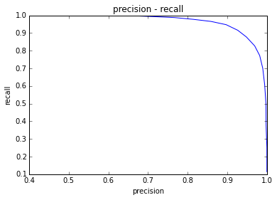

```python
%matplotlib inline
plt.plot(precision_list, recall_list)
plt.title('precision - recall')
plt.xlabel('precision')
plt.ylabel('recall')
plt.show()
```

#### 上の例では、全てのデータで学習し、それを元データに当てはめていたので、今度は学習データとテストデータを分ける

```python
# ランダムにデータを分ける
X_train, X_test, y_train, y_test  = train_test_split(
        corpus_data_features_nd[0:len(sentence_df)],
        sentence_df.Sentiment,
        train_size=0.85,
        random_state=1234)
```

```python
log_model = LogisticRegression()
log_model = log_model.fit(X=X_train, y=y_train)
y_pred = log_model.predict(X_test)
print(classification_report(y_test, y_pred))
```

```
             precision    recall  f1-score   support

          0       0.73      0.73      0.73       777
          1       0.75      0.74      0.74       823

avg / total       0.74      0.74      0.74      1600
```

```python
# 予測確率については、No.76のコードを参考にする
# (1となる)予測確率を取り出す
prob_list = []
for item in (log_model.predict_proba(X_test)).tolist():
    prob_list.append(item[1])
```

```python
# 正解のラベル
answer_list = y_test.tolist()
answer_list[:10]
```

```
[0, 1, 1, 1, 0, 0, 0, 1, 0, 1]
```

```python
# cf. http://inaba.hateblo.jp/entry/2014/12/30/232837

def pre_recl(answer_list, predicted_list):
    # TP, FP, TN, FNの計算
    TP = 0 ; FP = 0 ; TN = 0 ; FN = 0
    for ans, pred in zip(answer_list, predicted_list):
        if pred == 1 and ans == 1:
            TP += 1
        elif pred == 1 and ans == 0:
            FP += 1
        elif pred == 0 and ans == 0:
            TN += 1
        elif pred == 0 and ans == 1:
            FN += 1
        else:
            print("Something is wrong.")

    precision = TP / (TP + FP)
    recall = TP / (TP + FN)

    return precision, recall

precision, recall = pre_recl(answer_list, predicted_list)
```

```python
def frange(x, y, jump): # float(小数)を含む場合のrange
    while x < y:
        yield x
        x += jump

precision_list = []
recall_list = []
for threshold in frange(0.00, 1.00, 0.05):
    precision, recall = no_79(threshold, answer_list)
    precision_list.append(precision)
    recall_list.append(recall)
```

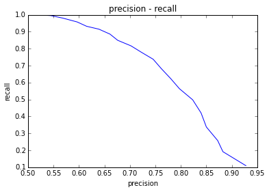

```python
%matplotlib inline
plt.plot(precision_list, recall_list)
plt.title('precision - recall')
plt.xlabel('precision')
plt.ylabel('recall')
plt.show()
```